# Project: Wrangle and Analyze Data - Analyze

```python
# prerequisite package imports
import numpy as np
import pandas as pd
import matplotlib.pyplot as plt
import seaborn as sns

%matplotlib inline
```

## Gather

To break the data wrangling and analysis process the analysis process needs to convert the timestamp, retweet_count and favorite_count before process. In addition, the dataframe is augmented with the time_of_day and text_length columns. These column additions can be done in Data Wrangling but since it is specific to this analysis. The decision is to augument it here to make it loosely coupled with the source data.

```python
df = pd.read_csv("twitter_analysis_source.csv")

df["timestamp"] = pd.to_datetime(df["timestamp"])
df["retweet_count"] = df.retweet_count.astype('Int64')
df["favorite_count"] = df.favorite_count.astype('Int64')
df["time_of_day"] = df.timestamp.dt.hour
df["text_length"] = df.text.str.len()
df["period"] = df.timestamp.dt.year.astype(str).str.cat(df.timestamp.dt.month.astype(str), sep="-")

df.describe()
```

|  | tweet_id | rating_numerator | rating_denominator | retweet_count | favorite_count | dog_rating | time_of_day | text_length |
| --- | --- | --- | --- | --- | --- | --- | --- | --- |
| count | 1.964000e+03 | 1964.000000 | 1964.0 | 1964.000000 | 1964.000000 | 1964.000000 | 1964.000000 | 1964.000000 |
| mean | 7.358154e+17 | 12.223014 | 10.0 | 2462.960794 | 8290.941446 | 1.222301 | 9.732179 | 122.509674 |
| std | 6.744191e+16 | 41.708155 | 0.0 | 4399.209019 | 12188.204717 | 4.170816 | 8.627077 | 25.848700 |
| min | 6.660209e+17 | 0.000000 | 10.0 | 11.000000 | 70.000000 | 0.000000 | 0.000000 | 36.000000 |
| 25% | 6.758399e+17 | 10.000000 | 10.0 | 549.500000 | 1780.250000 | 1.000000 | 1.000000 | 106.000000 |
| 50% | 7.087246e+17 | 11.000000 | 10.0 | 1190.500000 | 3750.000000 | 1.100000 | 4.000000 | 132.000000 |
| 75% | 7.877408e+17 | 12.000000 | 10.0 | 2814.000000 | 10345.250000 | 1.200000 | 18.000000 | 139.000000 |
| max | 8.924206e+17 | 1776.000000 | 10.0 | 77495.000000 | 155538.000000 | 177.600000 | 23.000000 | 167.000000 |

## Analyze

### Tweet Source

The majority of the uses appear to be posting from the iPhone client. This appears reasonable since the tweet requires the poster to send in a photo of their Dogs which is easier with a mobile device. And the iPhone is one of the most popular devices.

```
Twitter for iPhone    1926
Twitter Web Client      28
TweetDeck               10
Name: source, dtype: int64
```

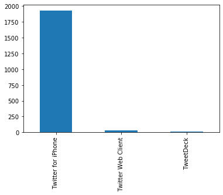

```python
display(df.source.value_counts())
df['source'].value_counts().plot(kind='bar');
```

### Time of the day

It appears that most of the Tweets occur from 15:00 to 05:00 UTC and there are very little or no Tweets from 06:00 to 14:00 UTC. Looking into the time conversions it is highly likely that the Tweets are based in United States. The data population comes from WeRateDogs which originated from a Twitter account based in North Carolina, United States. This data makes sense since it is likely that the followers of the account are based in United States

#### UTC 06:00

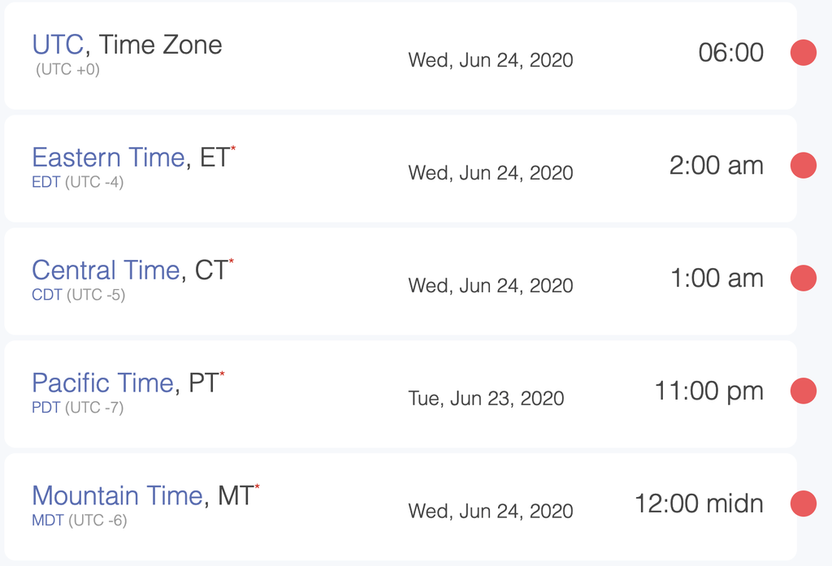

#### UTC 14:00

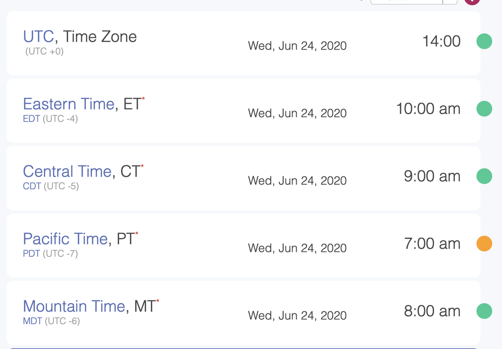

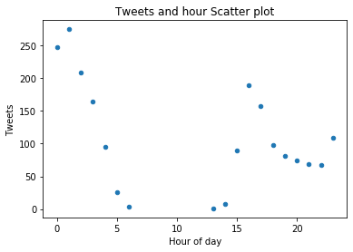

```python
df_time_of_day = df.time_of_day.value_counts().rename_axis('hour').reset_index(name='tweets')
df_time_of_day.plot(kind='scatter',x='hour',y='tweets');
plt.xlabel('Hour of day');
plt.ylabel('Tweets');
plt.title('Tweets and hour Scatter plot');
```

```python
df.info()
```

```
<class 'pandas.core.frame.DataFrame'>
RangeIndex: 1964 entries, 0 to 1963
Data columns (total 15 columns):
 #   Column              Non-Null Count  Dtype
---  ------              --------------  -----
 0   tweet_id            1964 non-null   int64
 1   timestamp           1964 non-null   datetime64[ns, UTC]
 2   source              1964 non-null   object
 3   text                1964 non-null   object
 4   rating_numerator    1964 non-null   int64
 5   rating_denominator  1964 non-null   int64
 6   breed               1659 non-null   object
 7   full_text           1964 non-null   object
 8   retweet_count       1964 non-null   Int64
 9   favorite_count      1964 non-null   Int64
 10  weekend             1964 non-null   bool
 11  dog_rating          1964 non-null   float64
 12  time_of_day         1964 non-null   int64
 13  text_length         1964 non-null   int64
 14  period              1964 non-null   object
dtypes: Int64(2), bool(1), datetime64[ns, UTC](1), float64(1), int64(5), object(5)
memory usage: 220.7+ KB
```

### Feature Correlation

Looking into the feature correlations it appears that the retweet count and favorite displays a high correlation. The higher the retweet the higher the favorite count.

```python
df_correlation = df[["rating_numerator", "retweet_count", "favorite_count", "time_of_day", "text_length"]]
df_correlation.corr(method ='pearson')
```

|  | rating_numerator | retweet_count | favorite_count | time_of_day | text_length |
| --- | --- | --- | --- | --- | --- |
| rating_numerator | 1.000000 | 0.019018 | 0.016754 | 0.012608 | -0.057715 |
| retweet_count | 0.019018 | 1.000000 | 0.929081 | 0.046104 | 0.041150 |
| favorite_count | 0.016754 | 0.929081 | 1.000000 | 0.048602 | 0.131612 |
| time_of_day | 0.012608 | 0.046104 | 0.048602 | 1.000000 | 0.099163 |
| text_length | -0.057715 | 0.041150 | 0.131612 | 0.099163 | 1.000000 |

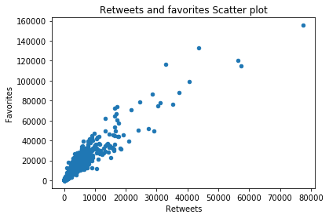

```python
df_correlation.plot(kind='scatter',x='retweet_count',y='favorite_count');
plt.xlabel('Retweets');
plt.ylabel('Favorites');
plt.title('Retweets and favorites Scatter plot');
```

### Breed Analysis

The data is group by the breed that is predicted by the image model. The breed assigned was an identified dog breed that has the highest confidence in the model. It appears that golden_retriever, Labrador_retriever, Pembroke and Chihuahua appears to be the predicted breeds that has the most tweets in the population. They account for 26% of the entire population. These 4 breeds also appear to top the retweets and favorites in the same ranking. This is understandable due to the higher number of tweets compared to other breeds.

It gets interesting when looking into the retweets and favorites of the breeds that are lower than 3%. The ranking no longer follows the same sequence.

```python
df_breed = df.groupby(["breed"]).agg(
    retweet_count=('retweet_count', 'sum'),
    favorite_count=('favorite_count', 'sum'),
    dog_rating=('dog_rating', 'mean'),
    text_length=('text_length', 'mean'),
    tweet_count=('tweet_id', 'count')
).reset_index()

def calculate_percentage(row, column, total):
    return row[column] / total * 100;

df_breed["tweet_percentage"] = df_breed.apply(
    lambda row: calculate_percentage(row, "tweet_count", df_breed["tweet_count"].sum()), axis=1
)

df_breed["favorite_percentage"] = df_breed.apply(
    lambda row: calculate_percentage(row, "favorite_count", df_breed["favorite_count"].sum()), axis=1
)

df_breed["retweet_percentage"] = df_breed.apply(
    lambda row: calculate_percentage(row, "retweet_count", df_breed["retweet_count"].sum()), axis=1
)
```

```python
df_top_10_tweet = df_breed.sort_values(["tweet_count"], ascending=False).head(10)
df_top_10_tweet
```

|  | breed | retweet_count | favorite_count | dog_rating | text_length | tweet_count | tweet_percentage | favorite_percentage | retweet_percentage |
| --- | --- | --- | --- | --- | --- | --- | --- | --- | --- |
| 89 | golden_retriever | 519243 | 1796967 | 1.217949 | 119.961538 | 156 | 9.403255 | 12.593699 | 12.489561 |
| 37 | Labrador_retriever | 345880 | 1117002 | 1.370192 | 123.375000 | 104 | 6.268837 | 7.828295 | 8.319591 |
| 49 | Pembroke | 257501 | 965907 | 1.142553 | 124.287234 | 94 | 5.666064 | 6.769374 | 6.193775 |
| 16 | Chihuahua | 229501 | 714857 | 1.050000 | 121.577778 | 90 | 5.424955 | 5.009938 | 5.520280 |
| 101 | pug | 103108 | 348478 | 1.024194 | 116.483871 | 62 | 3.737191 | 2.442241 | 2.480098 |
| 108 | toy_poodle | 97328 | 294107 | 1.097959 | 121.265306 | 49 | 2.953586 | 2.061193 | 2.341070 |
| 81 | chow | 116942 | 416549 | 1.416667 | 114.562500 | 48 | 2.893309 | 2.919304 | 2.812853 |
| 50 | Pomeranian | 99765 | 294142 | 1.253659 | 120.878049 | 41 | 2.471368 | 2.061438 | 2.399688 |
| 55 | Samoyed | 169581 | 514385 | 1.173171 | 121.121951 | 41 | 2.471368 | 3.604969 | 4.079000 |
| 95 | malamute | 96454 | 325794 | 1.087879 | 123.515152 | 33 | 1.989150 | 2.283265 | 2.320047 |

```python
df_top_10_fav = df_breed.sort_values(["favorite_count"], ascending=False).head(10)
df_top_10_fav
```

|  | breed | retweet_count | favorite_count | dog_rating | text_length | tweet_count | tweet_percentage | favorite_percentage | retweet_percentage |
| --- | --- | --- | --- | --- | --- | --- | --- | --- | --- |
| 89 | golden_retriever | 519243 | 1796967 | 1.217949 | 119.961538 | 156 | 9.403255 | 12.593699 | 12.489561 |
| 37 | Labrador_retriever | 345880 | 1117002 | 1.370192 | 123.375000 | 104 | 6.268837 | 7.828295 | 8.319591 |
| 49 | Pembroke | 257501 | 965907 | 1.142553 | 124.287234 | 94 | 5.666064 | 6.769374 | 6.193775 |
| 16 | Chihuahua | 229501 | 714857 | 1.050000 | 121.577778 | 90 | 5.424955 | 5.009938 | 5.520280 |
| 23 | French_bulldog | 143816 | 560980 | 1.116667 | 134.466667 | 30 | 1.808318 | 3.931521 | 3.459264 |
| 55 | Samoyed | 169581 | 514385 | 1.173171 | 121.121951 | 41 | 2.471368 | 3.604969 | 4.079000 |
| 81 | chow | 116942 | 416549 | 1.416667 | 114.562500 | 48 | 2.893309 | 2.919304 | 2.812853 |
| 83 | cocker_spaniel | 129549 | 377429 | 1.133333 | 119.000000 | 30 | 1.808318 | 2.645139 | 3.116094 |
| 101 | pug | 103108 | 348478 | 1.024194 | 116.483871 | 62 | 3.737191 | 2.442241 | 2.480098 |
| 95 | malamute | 96454 | 325794 | 1.087879 | 123.515152 | 33 | 1.989150 | 2.283265 | 2.320047 |

```python
df_top_10_retweet = df_breed.sort_values(["retweet_count"], ascending=False).head(10)
df_top_10_retweet
```

|  | breed | retweet_count | favorite_count | dog_rating | text_length | tweet_count | tweet_percentage | favorite_percentage | retweet_percentage |
| --- | --- | --- | --- | --- | --- | --- | --- | --- | --- |
| 89 | golden_retriever | 519243 | 1796967 | 1.217949 | 119.961538 | 156 | 9.403255 | 12.593699 | 12.489561 |
| 37 | Labrador_retriever | 345880 | 1117002 | 1.370192 | 123.375000 | 104 | 6.268837 | 7.828295 | 8.319591 |
| 49 | Pembroke | 257501 | 965907 | 1.142553 | 124.287234 | 94 | 5.666064 | 6.769374 | 6.193775 |
| 16 | Chihuahua | 229501 | 714857 | 1.050000 | 121.577778 | 90 | 5.424955 | 5.009938 | 5.520280 |
| 55 | Samoyed | 169581 | 514385 | 1.173171 | 121.121951 | 41 | 2.471368 | 3.604969 | 4.079000 |
| 23 | French_bulldog | 143816 | 560980 | 1.116667 | 134.466667 | 30 | 1.808318 | 3.931521 | 3.459264 |
| 83 | cocker_spaniel | 129549 | 377429 | 1.133333 | 119.000000 | 30 | 1.808318 | 2.645139 | 3.116094 |
| 81 | chow | 116942 | 416549 | 1.416667 | 114.562500 | 48 | 2.893309 | 2.919304 | 2.812853 |
| 101 | pug | 103108 | 348478 | 1.024194 | 116.483871 | 62 | 3.737191 | 2.442241 | 2.480098 |
| 50 | Pomeranian | 99765 | 294142 | 1.253659 | 120.878049 | 41 | 2.471368 | 2.061438 | 2.399688 |

### Dog Rating

Dog Rating which is a value that is populated by the Tweet poster appears to be random and appears to be bias towards the breeds showing higher dog_rating for breeds with lesser Tweet counts. In this study, the is calculated by dividing a numerator which can be more than 10 by a denominator that is fixed at 10. The only exception is the Labrador_retriever which is one of the breeds with most tweets. Another observation by looking into the top 10 breeds by tweet count shows that the majority of the posters tend to prefer giving a rating of 1.0 to 1.4.

|  | breed | retweet_count | favorite_count | dog_rating | text_length | tweet_count | tweet_percentage | favorite_percentage | retweet_percentage |
| --- | --- | --- | --- | --- | --- | --- | --- | --- | --- |
| 82 | clumber | 1634 | 6615 | 2.700000 | 161.000000 | 1 | 0.060277 | 0.046360 | 0.039303 |
| 105 | soft-coated_wheaten_terrier | 13007 | 43467 | 2.135714 | 113.285714 | 14 | 0.843882 | 0.304630 | 0.312863 |
| 68 | West_Highland_white_terrier | 20705 | 88593 | 1.468750 | 128.500000 | 16 | 0.964436 | 0.620887 | 0.498026 |
| 28 | Great_Pyrenees | 59060 | 169022 | 1.466667 | 123.133333 | 15 | 0.904159 | 1.184558 | 1.420594 |
| 81 | chow | 116942 | 416549 | 1.416667 | 114.562500 | 48 | 2.893309 | 2.919304 | 2.812853 |
| 37 | Labrador_retriever | 345880 | 1117002 | 1.370192 | 123.375000 | 104 | 6.268837 | 7.828295 | 8.319591 |
| 76 | borzoi | 13809 | 48904 | 1.360000 | 124.100000 | 10 | 0.602773 | 0.342734 | 0.332153 |
| 60 | Siberian_husky | 29967 | 127496 | 1.325000 | 122.250000 | 20 | 1.205546 | 0.893531 | 0.720808 |
| 11 | Bouvier_des_Flandres | 3901 | 16404 | 1.300000 | 162.000000 | 1 | 0.060277 | 0.114964 | 0.093832 |
| 50 | Pomeranian | 99765 | 294142 | 1.253659 | 120.878049 | 41 | 2.471368 | 2.061438 | 2.399688 |
| 54 | Saluki | 17992 | 88515 | 1.250000 | 126.000000 | 4 | 0.241109 | 0.620340 | 0.432769 |
| 78 | briard | 7790 | 25920 | 1.233333 | 113.000000 | 3 | 0.180832 | 0.181655 | 0.187376 |
| 63 | Tibetan_mastiff | 14571 | 44144 | 1.225000 | 89.250000 | 4 | 0.241109 | 0.309375 | 0.350482 |
| 89 | golden_retriever | 519243 | 1796967 | 1.217949 | 119.961538 | 156 | 9.403255 | 12.593699 | 12.489561 |
| 9 | Border_terrier | 20829 | 86919 | 1.214286 | 134.428571 | 7 | 0.421941 | 0.609155 | 0.501008 |

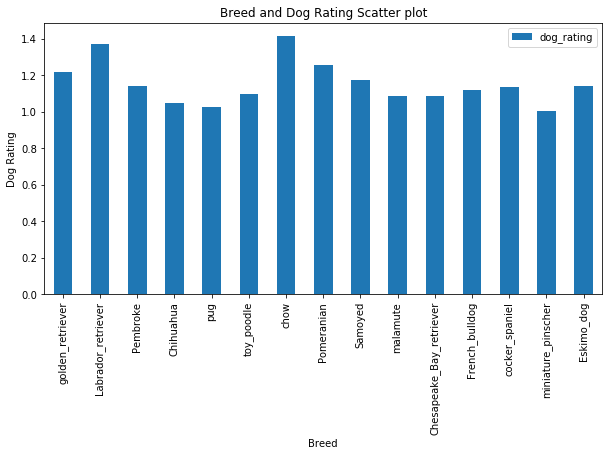

```python
df_breed.sort_values(by="tweet_count", ascending=False).head(15).plot(kind='bar',x='breed',y='dog_rating',figsize=(10,5));
plt.xlabel('Breed');
plt.ylabel('Dog Rating');
plt.title('Breed and Dog Rating Scatter plot');

df_breed.sort_values(by="dog_rating", ascending=False).head(15)
```

### Period Analysis

Looking into the tweet counts over a monthly period form 2015-11 till 2017-07. 2017-08 is taken out of consideration as that was the cutoff for the Tweets which most likely cause the low number of tweets. Looking into the trending Tweet account. It appears that the peak happen in around 2015-11 to 2016-01 where 2015 was the year the thread started. There was another peak about 2016-2 to 2016-3. Between 2016-4 till 2017-2 the tweet count trended around the 60s. Then starting from 2017-3 another dip occurred and since then it hovered around 40 tweets per month.

```python
df_period = df.groupby(["period"]).agg(
    retweet_count=('retweet_count', 'sum'),
    favorite_count=('favorite_count', 'sum'),
    dog_rating=('dog_rating', 'mean'),
    text_length=('text_length', 'mean'),
    tweet_count=('tweet_id', 'count')
).reset_index()

df_period
```

|  | period | retweet_count | favorite_count | dog_rating | text_length | tweet_count |
| --- | --- | --- | --- | --- | --- | --- |
| 0 | 2015-11 | 143412 | 347070 | 1.027458 | 122.650847 | 295 |
| 1 | 2015-12 | 473755 | 1161082 | 1.019499 | 115.150418 | 359 |
| 2 | 2016-1 | 223604 | 613249 | 1.073494 | 117.668675 | 166 |
| 3 | 2016-10 | 243166 | 785509 | 1.267692 | 117.584615 | 65 |
| 4 | 2016-11 | 224002 | 704031 | 1.203846 | 114.461538 | 52 |
| 5 | 2016-12 | 264224 | 827435 | 1.216667 | 125.296296 | 54 |
| 6 | 2016-2 | 154990 | 434375 | 1.087037 | 117.092593 | 108 |
| 7 | 2016-3 | 170834 | 496463 | 1.202542 | 118.084746 | 118 |
| 8 | 2016-4 | 76690 | 235222 | 1.114815 | 113.444444 | 54 |
| 9 | 2016-5 | 109611 | 322596 | 1.430357 | 110.625000 | 56 |
| 10 | 2016-6 | 310547 | 780729 | 1.021519 | 122.341772 | 79 |
| 11 | 2016-7 | 192549 | 566105 | 3.286207 | 118.862069 | 87 |
| 12 | 2016-8 | 189782 | 558504 | 1.093220 | 123.864407 | 59 |
| 13 | 2016-9 | 198850 | 641105 | 1.143548 | 124.854839 | 62 |
| 14 | 2017-1 | 373763 | 1205814 | 1.336364 | 125.893939 | 66 |
| 15 | 2017-2 | 240297 | 1068929 | 1.217460 | 142.555556 | 63 |
| 16 | 2017-3 | 185515 | 823712 | 1.231111 | 141.622222 | 45 |
| 17 | 2017-4 | 207767 | 863556 | 1.222500 | 150.575000 | 40 |
| 18 | 2017-5 | 292101 | 1171517 | 1.276190 | 145.476190 | 42 |
| 19 | 2017-6 | 249420 | 1152523 | 1.248837 | 147.186047 | 43 |
| 20 | 2017-7 | 299022 | 1456717 | 1.263265 | 139.632653 | 49 |
| 21 | 2017-8 | 13354 | 67166 | 1.300000 | 135.500000 | 2 |

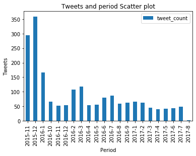

```python
df_period.plot(kind='bar',x='period',y='tweet_count');
plt.xlabel('Period');
plt.ylabel('Tweets');
plt.title('Tweets and period Scatter plot');
```